# Linear model

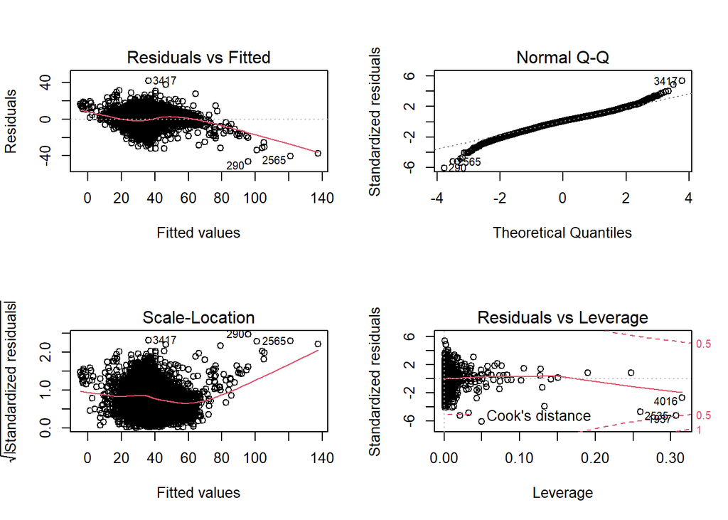

```r
par(mfrow=c(2,2))
plot(model_3)
```

VIF measure the severity of multicollinearity in multiple linear regression model.If the variance expansion factor is more than 10, the regression model has serious multicollinearity. We can find that the multiple linear model after stepwise regression has strong collinearity

```r
# model_3 has high collinearity
vif(model_3)
```

```
##     Group1_6    Group1_11    Group1_20     Group2_4    Group2_14    Group3_11
##     4.041876     1.703593     3.552852     2.080340     1.727955     1.378222
##    Group11_4    Group11_6    Group9_23    Group9_24    Group9_25    Group9_26
##   148.335678   149.450524  7778.254561 39983.934015 74735.309580 23651.363495
##    Group9_54    Group13_5    Group13_6    Group13_9   Group13_20   Group13_34
##     1.214796     8.698016     6.974558     8.841613    48.258012    20.602836
##   Group13_35   Group13_36   Group13_46   Group13_47   Group13_62   Group13_63
##     1.937368     2.281683   160.328669   314.212360   443.451464   426.675993
```

```r
# The variables after stepwise regression construct a new data set
Data_select <- select(Data_remove,Group1_6,Group1_11,Group1_20,Group2_4,
                      Group2_14,Group3_11,Group11_4,Group11_6,Group9_23,
                      Group9_24,Group9_25,Group9_26,Group9_54,Group13_5,
                    Group13_6,Group13_9,Group13_20,Group13_34,Group13_35,
                    Group13_36,Group13_46,Group13_47,Group13_62,Group13_63,
                    Response)
```

Show the correlation between the same group of variables in the remaining variables

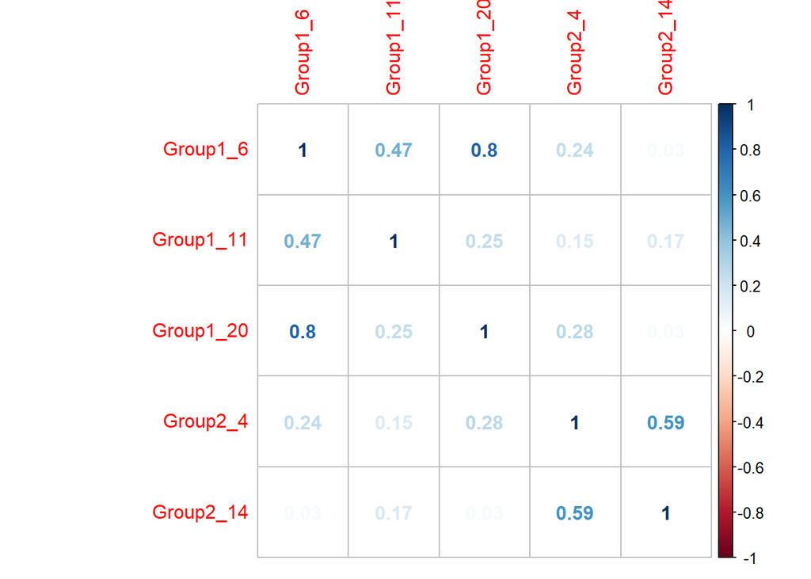

```r
library(corrplot)
# Correlation coefficient of Group_1 and Group2 variables
cor_Group1 <- data.matrix(select(Data_select, c('Group1_6','Group1_11','Group1_20','Group2_4','Group2_14')))
corrplot(cor(cor_Group1),method = "number")
```

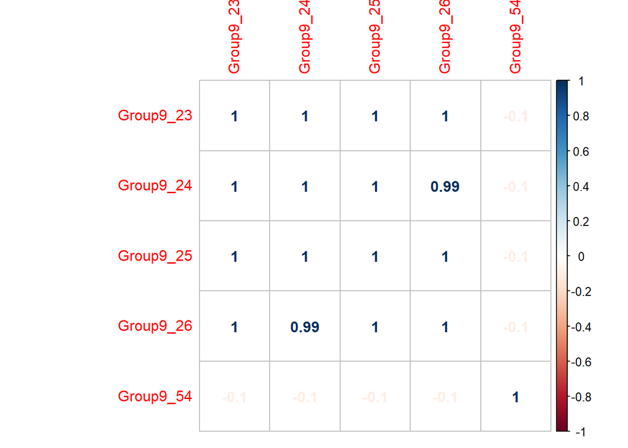

```r
# Correlation coefficient of Group_9 variables
cor_Group9 <- data.matrix(select(Data_select, c('Group9_23','Group9_24','Group9_25','Group9_26','Group9_54')))
corrplot(cor(cor_Group9),method = "number")
```

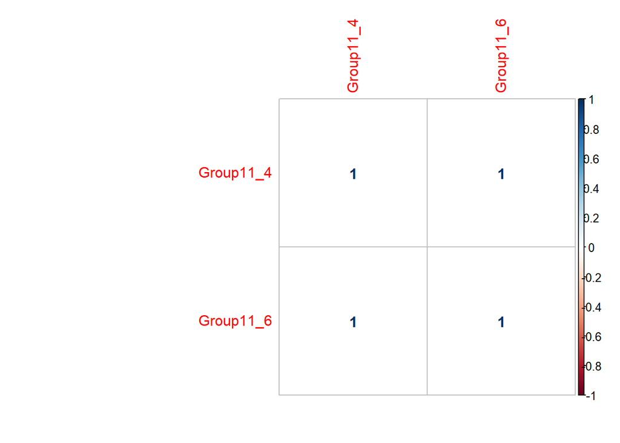

```r
# Correlation coefficient of Group_11 variables
cor_Group11 <- data.matrix(select(Data_select, c('Group11_4','Group11_6')))
corrplot(cor(cor_Group11),method = "number")
```

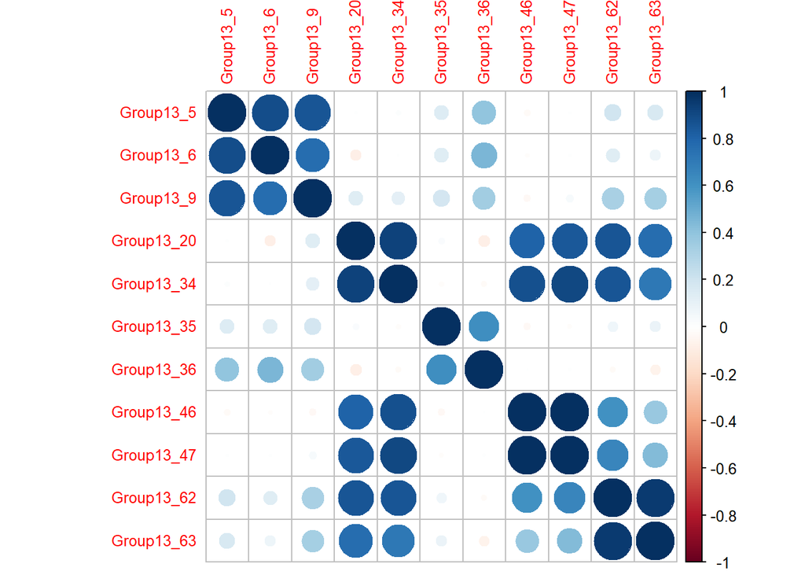

```r
# Correlation coefficient of Group_13 variables
cor_Group13 <- data.matrix(select(Data_select, c('Group13_5','Group13_6','Group13_9','Group13_20','Group13_34','Group13_35',
  'Group13_36','Group13_46','Group13_47','Group13_62','Group13_63',)))
corrplot(cor(cor_Group13),tl.cex = 0.8)
```

Some variables in model_3 fail to pass the significance test. We will continue to process them with drop1()

```r
drop1(model_3,test = 'F')
```

```
## Single term deletions
##
## Model:
## Response ~ Group1_6 + Group1_11 + Group1_20 + Group2_4 + Group2_14 +
##     Group3_11 + Group11_4 + Group11_6 + Group9_23 + Group9_24 +
##     Group9_25 + Group9_26 + Group9_54 + Group13_5 + Group13_6 +
##     Group13_9 + Group13_20 + Group13_34 + Group13_35 + Group13_36 +
##     Group13_46 + Group13_47 + Group13_62 + Group13_63
##            Df Sum of Sq    RSS   AIC   F value    Pr(>F)
## <none>                  385017 26147
## Group1_6    1      1607 386625 26171   26.4478 2.789e-07 ***
## Group1_11   1    231961 616978 29144 3816.6470 < 2.2e-16 ***
## Group1_20   1       572 385589 26154    9.4070 0.0021707 **
## Group2_4    1     12303 397320 26345  202.4302 < 2.2e-16 ***
## Group2_14   1     11552 396569 26333  190.0670 < 2.2e-16 ***
## Group3_11   1      1799 386816 26174   29.5934 5.528e-08 ***
## Group11_4   1       642 385659 26155   10.5594 0.0011620 **
## Group11_6   1       737 385754 26157   12.1239 0.0005012 ***
## Group9_23   1       990 386007 26161   16.2906 5.497e-05 ***
## Group9_24   1       801 385818 26158   13.1776 0.0002856 ***
## Group9_25   1       696 385713 26156   11.4474 0.0007203 ***
## Group9_26   1       794 385811 26158   13.0604 0.0003040 ***
## Group9_54   1      1029 386046 26162   16.9299 3.928e-05 ***
## Group13_5   1      3042 388060 26195   50.0584 1.653e-12 ***
## Group13_6   1      6377 391395 26249  104.9339 < 2.2e-16 ***
## Group13_9   1      1399 386416 26168   23.0109 1.648e-06 ***
## Group13_20  1      2492 387509 26186   41.0009 1.631e-10 ***
## Group13_34  1      2870 387887 26192   47.2272 6.926e-12 ***
## Group13_35  1       631 385648 26155   10.3760 0.0012831 **
## Group13_36  1       207 385224 26148    3.4106 0.0648235 .
## Group13_46  1       130 385147 26147    2.1422 0.1433489
## Group13_47  1      2324 387341 26183   38.2389 6.649e-10 ***
## Group13_62  1      1718 386735 26173   28.2688 1.092e-07 ***
## Group13_63  1      3004 388021 26194   49.4220 2.281e-12 ***
## ---
## Signif. codes:  0 '***' 0.001 '**' 0.01 '*' 0.05 '.' 0.1 ' ' 1
```

```r
# Remove Group13_46
model_4 <- lm(Response~ Group1_6+Group1_11+Group1_20+Group2_4+Group2_14+
                Group3_11+Group11_4+Group11_6+Group9_23+Group9_24+
                Group9_25+Group9_26+Group9_54+Group13_5+Group13_6+
                Group13_9+Group13_20+Group13_34+Group13_35+Group13_36+
                Group13_47+Group13_62+Group13_63,data = Data_remove)
drop1(model_4,test = 'F')
```

```
## Single term deletions
##
## Model:
## Response ~ Group1_6 + Group1_11 + Group1_20 + Group2_4 + Group2_14 +
##     Group3_11 + Group11_4 + Group11_6 + Group9_23 + Group9_24 +
##     Group9_25 + Group9_26 + Group9_54 + Group13_5 + Group13_6 +
##     Group13_9 + Group13_20 + Group13_34 + Group13_35 + Group13_36 +
##     Group13_47 + Group13_62 + Group13_63
##            Df Sum of Sq    RSS   AIC   F value    Pr(>F)
## <none>                  385147 26147
## Group1_6    1      1699 386846 26173   27.9451 1.290e-07 ***
## Group1_11   1    233781 618928 29162 3845.8945 < 2.2e-16 ***
## Group1_20   1       609 385757 26155   10.0216 0.0015544 **
## Group2_4    1     12360 397507 26346  203.3279 < 2.2e-16 ***
## Group2_14   1     11494 396642 26332  189.0937 < 2.2e-16 ***
## Group3_11   1      1743 386890 26174   28.6686 8.891e-08 ***
## Group11_4   1       640 385787 26155   10.5272 0.0011824 **
## Group11_6   1       732 385879 26157   12.0354 0.0005255 ***
## Group9_23   1      1013 386160 26162   16.6610 4.524e-05 ***
## Group9_24   1       773 385921 26158   12.7196 0.0003645 ***
## Group9_25   1       659 385806 26156   10.8330 0.0010025 **
## Group9_26   1       767 385915 26158   12.6248 0.0003834 ***
## Group9_54   1      1066 386214 26163   17.5407 2.850e-05 ***
## Group13_5   1      3561 388708 26203   58.5837 2.239e-14 ***
## Group13_6   1      6331 391478 26249  104.1440 < 2.2e-16 ***
## Group13_9   1      3570 388717 26204   58.7254 2.085e-14 ***
## Group13_20  1      2456 387603 26185   40.4013 2.212e-10 ***
## Group13_34  1      2779 387926 26191   45.7111 1.493e-11 ***
## Group13_35  1       669 385817 26156   11.0089 0.0009119 ***
## Group13_36  1       222 385369 26149    3.6484 0.0561678 .
## Group13_47  1      3772 388920 26207   62.0553 3.903e-15 ***
## Group13_62  1      1672 386820 26172   27.5131 1.611e-07 ***
## Group13_63  1      2955 388102 26194   48.6073 3.444e-12 ***
## ---
## Signif. codes:  0 '***' 0.001 '**' 0.01 '*' 0.05 '.' 0.1 ' ' 1
```

```r
# Remove Group13_36
```

```r
model_5 <- lm(Response~ Group1_6+Group1_11+Group1_20+Group2_4+Group2_14+
                Group3_11+Group11_4+Group11_6+Group9_23+Group9_24+
                Group9_25+Group9_26+Group9_54+Group13_5+Group13_6+
                Group13_9+Group13_20+Group13_34+Group13_35+
                Group13_47+Group13_62+Group13_63,data = Data_remove)
summary(model_5)
```

```
##
## Call:
## lm(formula = Response ~ Group1_6 + Group1_11 + Group1_20 + Group2_4 +
##     Group2_14 + Group3_11 + Group11_4 + Group11_6 + Group9_23 +
##     Group9_24 + Group9_25 + Group9_26 + Group9_54 + Group13_5 +
##     Group13_6 + Group13_9 + Group13_20 + Group13_34 + Group13_35 +
##     Group13_47 + Group13_62 + Group13_63, data = Data_remove)
##
## Residuals:
##     Min      1Q  Median      3Q     Max
## -45.894  -4.600   0.524   4.912  41.866
##
## Coefficients:
##               Estimate Std. Error t value Pr(>|t|)
## (Intercept)  2.433e+01  2.750e+00   8.847  < 2e-16 ***
## Group1_6    -5.460e+01  1.027e+01  -5.319 1.08e-07 ***
## Group1_11    5.175e+00  8.328e-02  62.141  < 2e-16 ***
## Group1_20    3.790e-01  1.177e-01   3.221 0.001286 **
## Group2_4     2.003e+01  1.409e+00  14.217  < 2e-16 ***
## Group2_14    5.893e+00  4.306e-01  13.684  < 2e-16 ***
## Group3_11    3.877e+01  7.344e+00   5.279 1.34e-07 ***
## Group11_4    1.965e+03  6.073e+02   3.236 0.001219 **
## Group11_6   -1.853e+01  5.357e+00  -3.459 0.000545 ***
## Group9_23   -2.456e+04  6.059e+03  -4.053 5.12e-05 ***
## Group9_24    8.299e+02  2.347e+02   3.536 0.000410 ***
## Group9_25   -1.473e+00  4.511e-01  -3.265 0.001101 **
## Group9_26    2.095e-01  5.935e-02   3.530 0.000419 ***
## Group9_54   -1.552e-04  3.657e-05  -4.244 2.23e-05 ***
## Group13_5    2.042e+01  2.640e+00   7.733 1.22e-14 ***
## Group13_6   -2.045e+00  2.040e-01 -10.023  < 2e-16 ***
## Group13_9   -2.130e+00  2.781e-01  -7.659 2.16e-14 ***
## Group13_20   1.024e-01  1.642e-02   6.235 4.81e-10 ***
## Group13_34   6.456e-02  9.043e-03   7.139 1.05e-12 ***
## Group13_35  -5.918e+00  2.167e+00  -2.730 0.006342 **
## Group13_47  -2.057e+00  2.628e-01  -7.828 5.79e-15 ***
## Group13_62   1.113e+02  2.165e+01   5.141 2.81e-07 ***
## Group13_63  -1.696e+02  2.453e+01  -6.912 5.26e-12 ***
## ---
## Signif. codes:  0 '***' 0.001 '**' 0.01 '*' 0.05 '.' 0.1 ' ' 1
##
## Residual standard error: 7.798 on 6337 degrees of freedom
## Multiple R-squared:  0.6216, Adjusted R-squared:  0.6203
## F-statistic: 473.1 on 22 and 6337 DF,  p-value: < 2.2e-16
```

```r
# All of the variables in model 5 passed the significance test
vif(model_5)
```

```
##     Group1_6    Group1_11    Group1_20     Group2_4    Group2_14    Group3_11
##     4.011322     1.692648     3.535786     2.078427     1.724041     1.369869
##    Group11_4    Group11_6    Group9_23    Group9_24    Group9_25    Group9_26
##   148.331562   149.436183  7769.449966 39889.682388 74376.931303 23602.962697
##    Group9_54    Group13_5    Group13_6    Group13_9   Group13_20   Group13_34
##     1.211075     8.178969     6.267044     4.997740    47.957674    19.922727
##   Group13_35   Group13_47   Group13_62   Group13_63
##     1.120618   129.643561   440.658641   425.397119
```

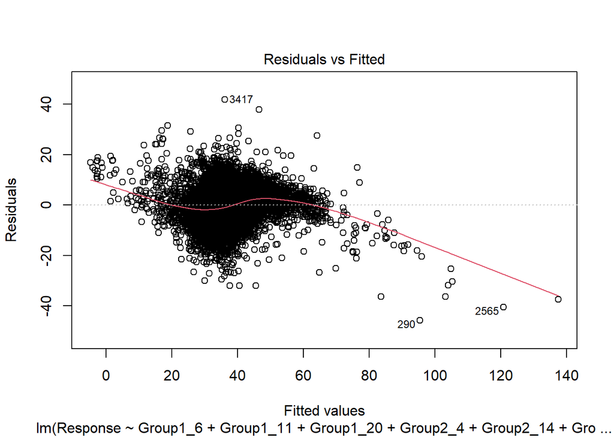

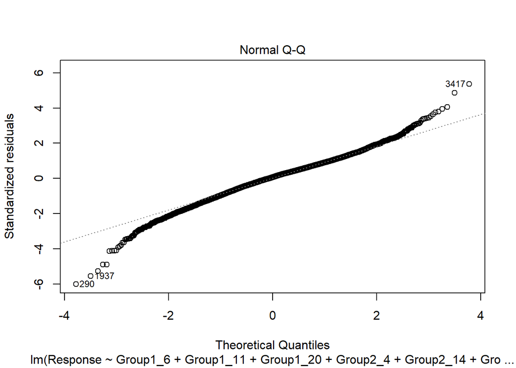

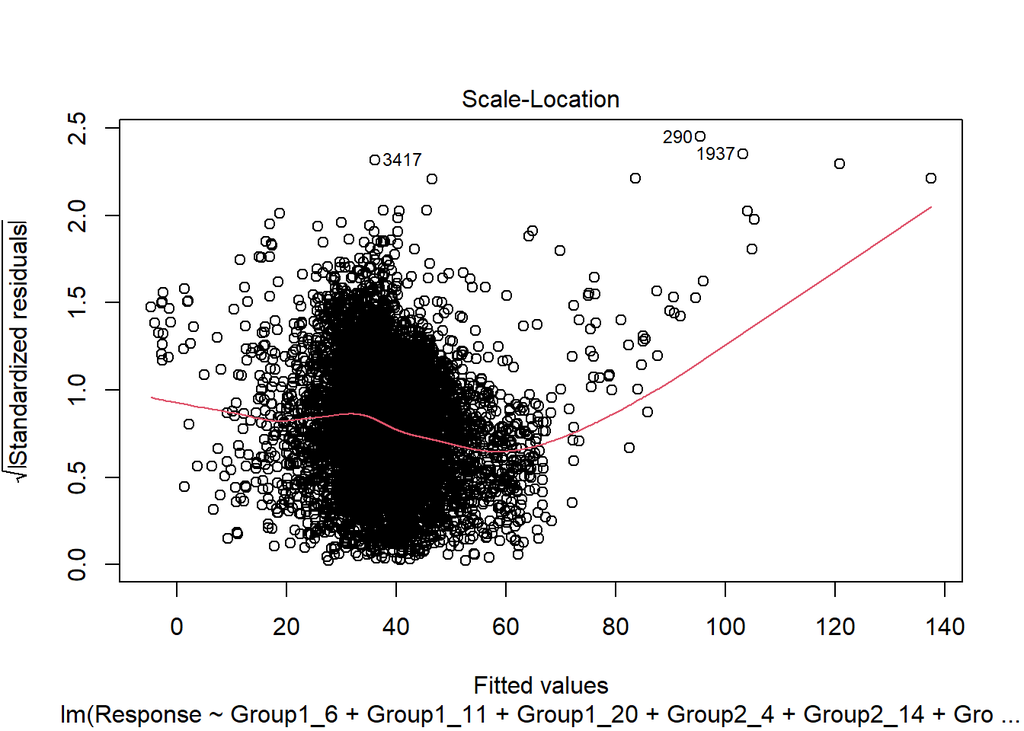

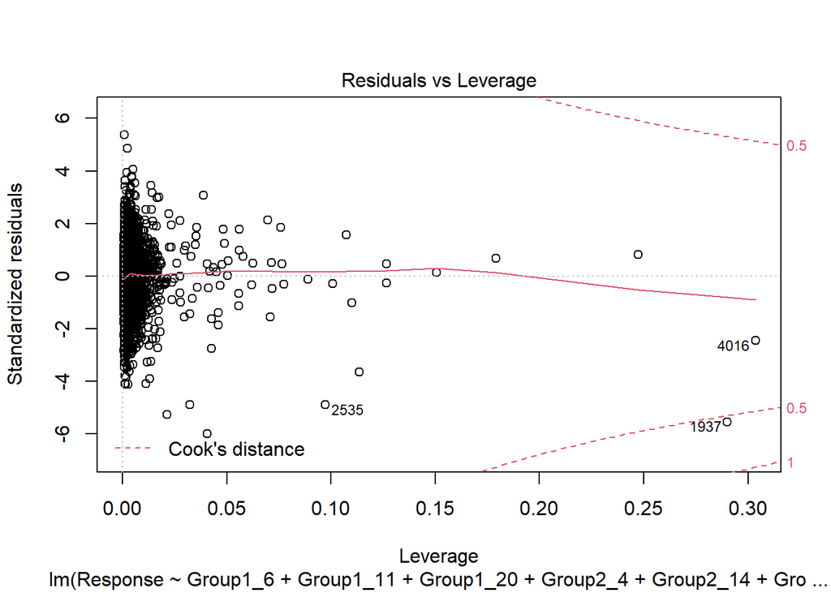

```r
plot(model_5)
```

Because the model has a serious collinearity problem, we will try to delete several collinear variables. Here I try to use PCA to solve the problem of multicollinearity, but the result is not very good, the linear model composed of principal components can not fit the data well (R-squared is aroud 0.47).